# La desigualdad de género se puede medir

Datos de la Encuesta Permanente de Hogares. 2do trimestre de 2019.

Julieta Moure<sup>1</sup>, Daiana Serpa<sup>2</sup>, Natsumi Shokida<sup>3</sup> para Economía Femini(s)ta

Abril de 2020

# Secciones

## Introducción

### Introducción

El objetivo de este informe es visibilizar las diferencias que, de acuerdo al género de las personas, pueden encontrarse en el ámbito del mercado de trabajo, los ingresos que perciben, la cantidad de horas que trabajan semanalmente, la distribución de las tareas domésticas. También se indaga sobre la expresión de estos mismos fenómenos en la distribución del ingreso a nivel social. Para ello se presenta una serie de indicadores, cuadros y gráficos de elaboración propia, que intentan responder preguntas como ¿Cómo se compone el mercado de trabajo de acuerdo al género de las personas?, ¿Hay diferencia entre varones y mujeres cuando hablamos de trabajo informal?¿Y cuando hablamos de cargos jerárquicos?, ¿Qué tanta diferencia hay entre los ingresos de los varones y de las mujeres?, ¿Los varones cobran más por cada hora trabajada?, ¿Trabajan las mujeres menos horas que los varones?, ¿Y qué pasa si consideramos trabajo no sólo a lo que se remunera sino también al trabajo doméstico?.  
Para realizar los cálculos se utilizan bases de datos publicadas por la Encuesta Permanente de Hogares del INDEC. Esta encuesta releva características demográficas, sociales, económicas, con especial atención a las formas de participación en el mercado laboral, entre hogares y personas de 31 aglomerados urbanos.  
Los indicadores presentados se encuentran desagregados según la variable disponible, que indica el *sexo* declarado por las personas respondentes de la encuesta, de acuerdo a una distinción *binaria*. Bregamos por la incorporación definitiva de una pregunta que nos permita tener información sobre la identidad de género de las personas en el próximo censo nacional, además de la referida al sexo asignado al nacer. La población trans-travesti históricamente ha sido excluida mediante violencia física, simbólica, psicológica, sexual y económica del sistema educativo, de salud y del trabajo formal. Dada la situación de vulnerabilidad a la que muches se enfrentan, resulta fundamental que estén presentes en las estadísticas oficiales.  
El documento se realizó utilizando el lenguaje de programación R, y para les curioses todo el código se encuentra disponible para su descarga<sup>4</sup>.  
Obviamente, estás invitade a utilizar estos datos en notas, reflexiones, trabajos, infografías, etc<sup>5</sup>. Además, si te gusta lo que hacemos podés apoyarnos potenciando nuestros proyectos, haciéndote socie del [#ClubEcofeminita o realizando una donación](https://donaronline.org/economia-femini-s-ta/club-ecofeminita).

<sup>1</sup> Julieta Moure es economista (FCE-UBA) y se encuentra maestrando en Políticas Públicas en la UTDT.  
<sup>2</sup> Daiana Serpa es economista (FCE-UBA) especializada en análisis de datos.  
<sup>3</sup> Natsumi Shokida es economista (FCE-UBA), coordinadora de EcoFemiData, el área de datos de [Economía Femini(s)ta](http://economiafeminita.com).  
<sup>4</sup> Presionando en_ **Code > Download Rmd** _se accede a la descarga de la sintaxis completa de este informe, que incluye la descarga automática de las bases de la EPH utilizadas, una serie de funciones útiles y la elaboración de cuadros y gráficos con el lenguaje R.  
<sup>5</sup> Si necesitás citarnos en un trabajo, podés hacerlo como: “Moure, J.; Serpa, D.; Shokida, N. (XX/XX/2020) La desigualdad de género se puede medir. 2do trimestre 2019. *Economía Femini(s)ta*. Recuperado de https://ecofeminita.github.io/EcoFemiData/informe_desigualdad_genero/trim_2018_04/informe.nb.html”

## Mercado de Trabajo

### Sobre la composición del Mercado de Trabajo

En esta sección se intenta dar cuenta de las asimetrías que existen en el mercado de trabajo en cuanto a su composición. Para esto se utilizan las tasas de actividad, empleo, desempleo y subocupación según el sexo de las personas, para ver qué tan masculinizado se encuentra el mismo y ver si las mujeres encuentran más problemas a la hora de conseguir un empleo. También se analizan estos indicadores teniendo en cuenta la edad de las personas, y se examina la incidencia de la informalidad en las relaciones de dependencia de asalariados y asalariadas. A su vez, se grafica la diferencia en acceso a cargos jerárquicos y la estructura de las diferentes ramas de ocupación, vinculando estos datos a las ideas de segregación vertical y horizontal en el mercado de trabajo.

#### Tasas básicas

**Figura 1.**

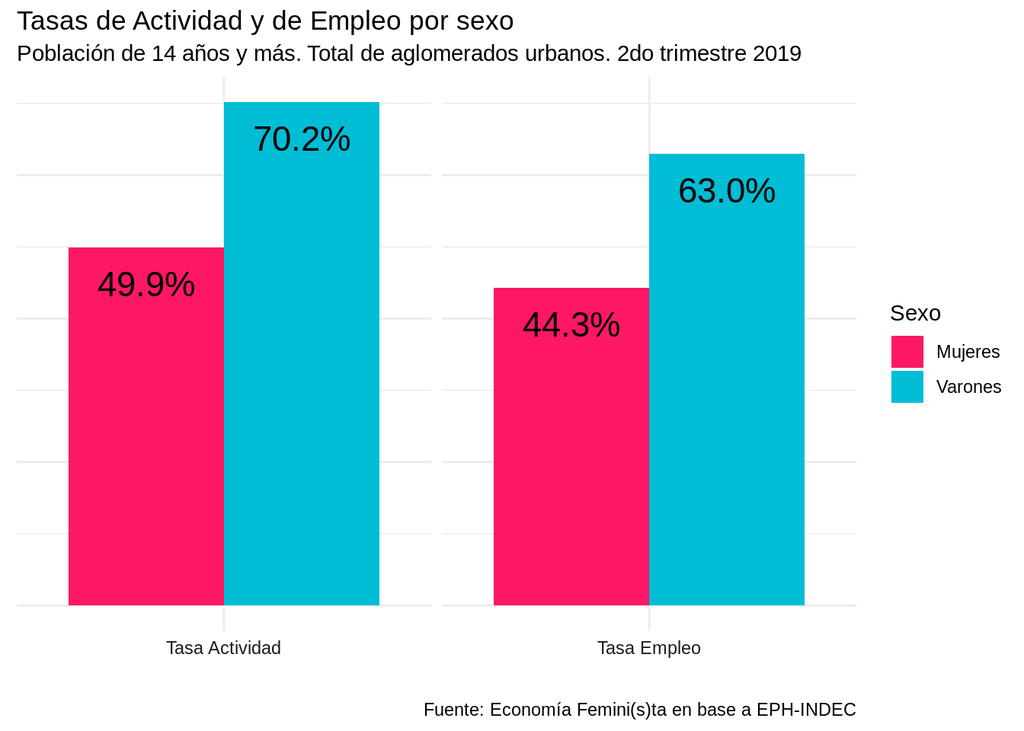

A diferencia de las tasas anteriores, las **tasas de desocupación y subocupación** expresan la proporción que estos grupos representan en la Población Económicamente Activa. En este caso, ambas tasas son mayores para las mujeres que para los varones. Esto señala que, incluso siendo minoría en el mercado de trabajo, las mujeres tendrían más dificultades para conseguir trabajo y/o para trabajar una jornada completa.  
En su conjunto, los cuatro indicadores presentados en esta sección muestran una primera imagen de la problemática que enfrentan las mujeres en el mercado de trabajo argentino.

**Figura 2.**

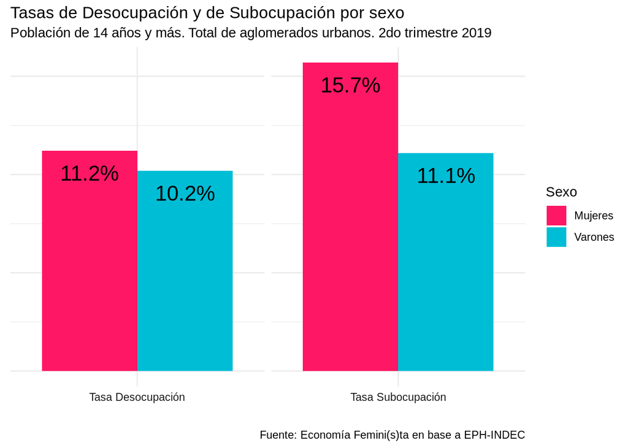

#### Por grupos de edad

A continuación se exponen los mismos indicadores, pero desagregados por grupos de edad además de por sexo.  
En este caso, llama la atención que son las mujeres más jóvenes las que presentan las mayores tasas de desocupación y subocupación. Para dar un ejemplo, **un 23.4% de las mujeres de 14 a 29 años está desocupada**, es decir que, no teniendo ocupación, están buscando activamente un trabajo y no lo consiguen. En cambio, en el caso de los varones jóvenes, el porcentaje de desocupados es de **18.6%.**  
Asimismo, se observa una sustancial diferencia en la tasa de actividad y empleo entre las mujeres y hombres de entre 30 y 64 años.

**Figura 3.**

**Principales Tasas del Mercado de Trabajo, por grupos de edad y sexo**

Población de 14 a 64 años. Total de aglomerados urbanos. 2do trimestre 2019

| Indicadores | de 14 a 29 años Mujeres | de 14 a 29 años Varones | de 30 a 64 años Mujeres | de 30 a 64 años Varones |
| --- | --- | --- | --- | --- |
| Tasa Actividad | 40.1% | 56.3% | 69.2% | 91.4% |
| Tasa Empleo | 30.7% | 45.8% | 63.9% | 85.0% |
| Tasa Desocupación | 23.4% | 18.6% | 7.6% | 7.1% |
| Tasa Subocupación | 17.4% | 13.1% | 15.6% | 10.2% |

Fuente: Economía Femini(s)ta en base a EPH-INDEC

#### Empleo no registrado

La falta de descuento jubilatorio suele ser un indicador que aproxima la falta de registro de la relación laboral asalariada. Como puede verse en el siguiente cuadro, la incidencia de esta problemática es mayor entre las asalariadas mujeres. En concreto, hay un **36.1%** de las asalariadas que por su trabajo realizado no posee descuentos jubilatorios, mientras que para los asalariados varones dicha tasa es del **33.2%.**

**Figura 4.**

**Empleo sin descuento jubilatorio por sexo**

Ocupadas/os asalariadas/os. Total de aglomerados urbanos. 2do trimestre 2019

| Sexo | Sin descuento jubilatorio |
| --- | --- |
| Mujeres | 36.1% |
| Varones | 33.2% |

Fuente: Economía Femini(s)ta en base a EPH-INDEC

#### Cargos jerárquicos

Además de tener una participación más restringida en el mercado de trabajo, las ocupadas encuentran más obstáculos para acceder a cargos jerárquicos: mientras que un **8.3%** de los ocupados varones tienen cargos de dirección o son jefes, un **4.9%** de las ocupadas ejercen puestos de esas características.  
Esta problemática es conocida como **Techo de Cristal** o **segregación vertical** del mercado de trabajo, y hace referencia a la dificultad que poseen las mujeres para ascender profesionalmente en el mercado laboral. Si se tiene en cuenta que el mercado de trabajo en general se encuentra masculinizado, estos porcentajes indican que hay muchas más probabilidades de tener un jefe o director varón en los espacios de trabajo.

**Figura 5.**

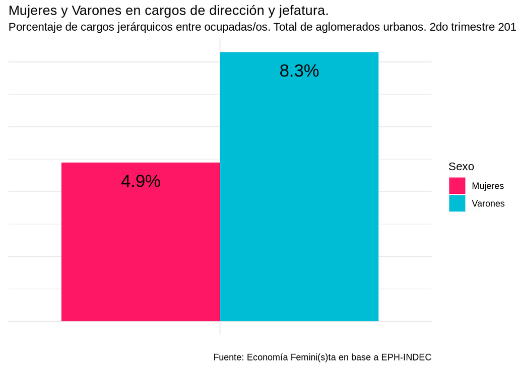

#### Ramas de la ocupación

La siguiente tabla representa al total de ocupadas y ocupados, según la rama de ocupación en la que se desempeñan. La tasa de feminización indica el porcentaje de mujeres que hay en cada una de ellas y, como puede observarse, las mujeres se encuentran sobrerrepresentadas en aquellos sectores vinculados al cuidado y las tareas de reproducción, como son el servicio doméstico, la enseñanza y los servicios sociales y de salud. Por su parte, sectores como la construcción, transporte y comunicaciones, las actividades primarias e incluso la industria manufacturera se encuentran masculinizadas.  
Este fenómeno se conoce como **Paredes de Cristal** o **segregación horizontal**, y hace referencia a los muros invisibles que segmentan el mercado de trabajo de acuerdo a los estereotipos de género aún vigentes.

**Figura 6.**

**Indicadores por ramas de la ocupación**

Ocupadas/os. Tasa de feminización, ingreso mensual promedio, ingreso horario. Total de aglomerados urbanos. 2do trimestre 2019

| Rama de la ocupación | Tasa de feminización | Ingreso mensual promedio | Ingreso horario |
| --- | --- | --- | --- |
| Servicio domestico | 96.9% | $ 7.400 | $ 92 |
| Ensenanza | 75.1% | $21.600 | $218 |
| Servicios sociales y de salud | 69.7% | $27.000 | $198 |
| Hoteles y restaurantes | 50.8% | $15.000 | $ 95 |
| Administracion publica, defensa y seguridad social | 45.9% | $30.100 | $205 |
| Otros servicios comunitarios, sociales y personales | 45.3% | $16.500 | $137 |
| Comercio | 40.7% | $19.300 | $117 |
| Servicios financieros, de alquiler y empresariales | 39.4% | $30.600 | $202 |
| Industria manufacturera | 30.7% | $22.400 | $138 |
| Actividades no bien especificadas | 27.0% | $27.800 | $179 |
| Otras ramas | 24.2% | $27.700 | $171 |
| Actividades primarias | 15.9% | $38.800 | $224 |
| Transporte, almacenamiento y comunicaciones | 11.8% | $26.700 | $156 |
| Construccion | 2.9% | $18.100 | $122 |

Fuente: Economía Femini(s)ta en base a EPH-INDEC

## Ingresos

### Ingresos

En esta sección se coloca el foco en las diferencias de montos de ingresos que perciben los varones y las mujeres. Estos ingresos pueden provenir de diversas fuentes y al mismo tiempo pueden desagregarse según características adicionales de las personas o los puestos que desempeñan. A su vez, pueden distinguirse los ingresos mensuales y los ingresos por hora trabajada.  
Para dimensionar estas diferencias hacemos uso del concepto de “brecha”, que en este caso se calcula como la diferencia entre los ingresos promedios de los varones y las mujeres, expresada en términos del ingreso más alto. Es decir, que puede leerse como *“las mujeres perciben ingresos que, en promedio, son un …% menores que los de los varones”.*

#### Ingresos mensuales

##### **Brechas de ingresos mensuales**

Como se ve en el siguiente cuadro, para el caso de todas las personas perceptoras de ingresos, la brecha entre mujeres y varones respecto al ingreso total individual es de **27.2%**. Es decir, contemplando todos los ingresos que se perciben, sean de origen laboral o no laboral (como jubilaciones y pensiones, cuotas alimentarias, subsidios, etc.), las mujeres perciben ingresos que, en promedio, son un 27.2% menores que los de los varones.  
Simultáneamente, en el mercado de trabajo, las mujeres ganan en promedio un **26.1%** menos que los varones ($17.700 vs. $24.000 ). Estos datos corresponden a la totalidad de ocupadas/os, cualquiera sea su categoría ocupacional, calificación o jerarquía, y observando en este caso los ingresos provenientes de su ocupación principal.  
Si tomamos en cuenta únicamente a aquellas personas que no poseen descuentos jubilatorios, se observa cómo las mujeres ganan en promedio un **37.1%** menos que sus pares. Es decir que la brecha de ingresos entre las y los trabajadores se amplía cuando vemos a aquellas/os asalariadas/os que tienen peores condiciones de trabajo.  
Finalmente, puede observarse que también existe una brecha, aunque mucho menor, entre las jubilaciones que perciben las mujeres y los varones.

**Figura 7.**

**Brechas de ingresos mensuales**

Por poblaciones y tipos de ingresos. Total de aglomerados urbanos. 2do trimestre 2019

| Población | Ingreso | Brecha | Media del ingreso Mujeres | Media del ingreso Varones |
| --- | --- | --- | --- | --- |
| Perceptores de ingresos | Ingreso Total Individual | 27.2% | $18.300 | $25.100 |
| Ocupadas/os | Ingreso de la Ocupación Principal | 26.1% | $17.700 | $24.000 |
| Asalariadas/os sin desc. jubil. | Ingreso de la Ocupación Principal | 37.1% | $ 8.900 | $14.100 |
| Perceptores de jubilación | Jubilación | 17.9% | $14.200 | $17.300 |

Fuente: Economía Femini(s)ta en base a EPH-INDEC

##### **Brecha de ingresos mensuales por calificación del puesto de trabajo**

El siguiente gráfico señala cómo la brecha de ingresos mensuales de las/os ocupadas/os se mantiene incluso a iguales niveles de calificación del puesto de trabajo. Por ejemplo, mientras que los varones que trabajan en ocupaciones profesionales tienen un ingreso medio de $46.900, las mujeres ocupadas en ese mismo segmento perciben un ingreso medio de $36.800, es decir, un **21.6%** menos que los varones.  
En los puestos no calificados, los varones ganan $14.600 en promedio, al tiempo que las mujeres ganan alrededor de $9.200. Esta brecha es del **37.0%**.

**Figura 8.**

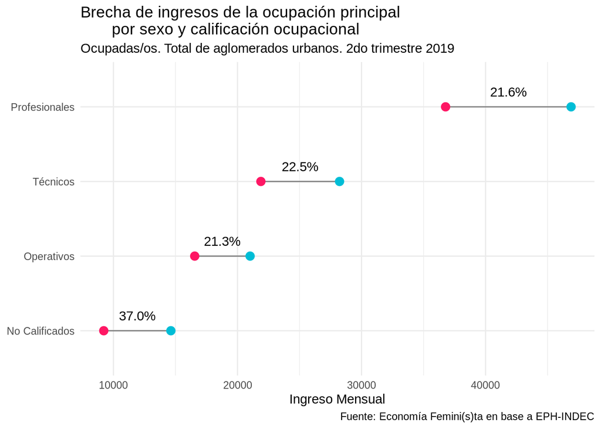

##### **Brecha de ingresos mensuales por nivel educativo**

Como puede observarse en el cuadro siguiente, el porcentaje de personas que cuentan con un nivel educativo superior es notablemente mayor entre las ocupadas mujeres, en comparación a los ocupados varones.  
Sin embargo, a igual nivel educativo, los ingresos laborales de las mujeres trabajadoras son inferiores a los de los varones. Esta diferencia de ingresos es del **29.9%** para las de nivel universitario/superior, y del **44.9%** para las que cuentan con nivel primario.

**Figura 9.**

**Nivel educativo de mujeres y varones**

Porcentaje por columnas. Ocupadas/os. Total de aglomerados urbanos. 2do trimestre 2019

| Nivel Educativo | Mujeres | Varones |
| --- | --- | --- |
| Sin Instrucción | 3.1% | 4.4% |
| Primaria | 23.0% | 34.5% |
| Secundaria | 42.9% | 42.5% |
| Superior | 31.1% | 18.5% |

Fuente: Economía Femini(s)ta en base a EPH-INDEC

**Figura 10.**

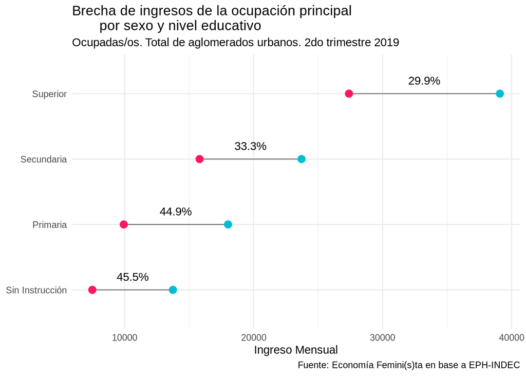

#### Ingresos horarios

##### **Brechas de ingresos horarios**

Si en lugar de comparar ingresos mensuales tomamos el ingreso por hora trabajada que perciben las personas, la historia es un poco diferente. En este caso, la brecha disminuye considerablemente. Que las brechas sean más amplias comparando ingresos mensuales de bolsillo, y que sean más estrechas cuando se toman los ingresos por hora, sugiere que las mujeres venden en el mercado de trabajo, por lo general, menos horas que los varones. Como se verá más adelante, esto está ligado al trabajo que las mismas suelen realizar al interior de los hogares.

**Figura 11.**

**Brechas de ingresos horarios**

Total de aglomerados urbanos. 2do trimestre 2019

| Población | Media del ingreso horario Mujeres | Media del ingreso horario Varones | Brecha |
| --- | --- | --- | --- |
| Ocupadas/os | $143 | $152 | 5.6% |
| Asalariadas/os | $152 | $154 | 0.8% |
| Asalariadas/os sin desc. jubil. | $ 99 | $103 | 3.2% |

Fuente: Economía Femini(s)ta en base a EPH-INDEC

##### **Brecha de ingresos horarios por nivel educativo**

Tal como se analizó en el caso anterior, si se observa la brecha de ingresos horarios por nivel educativo alcanzado, la misma se reduce significativamente, aunque sigue presente en algunas categorías.

**Figura 12.**

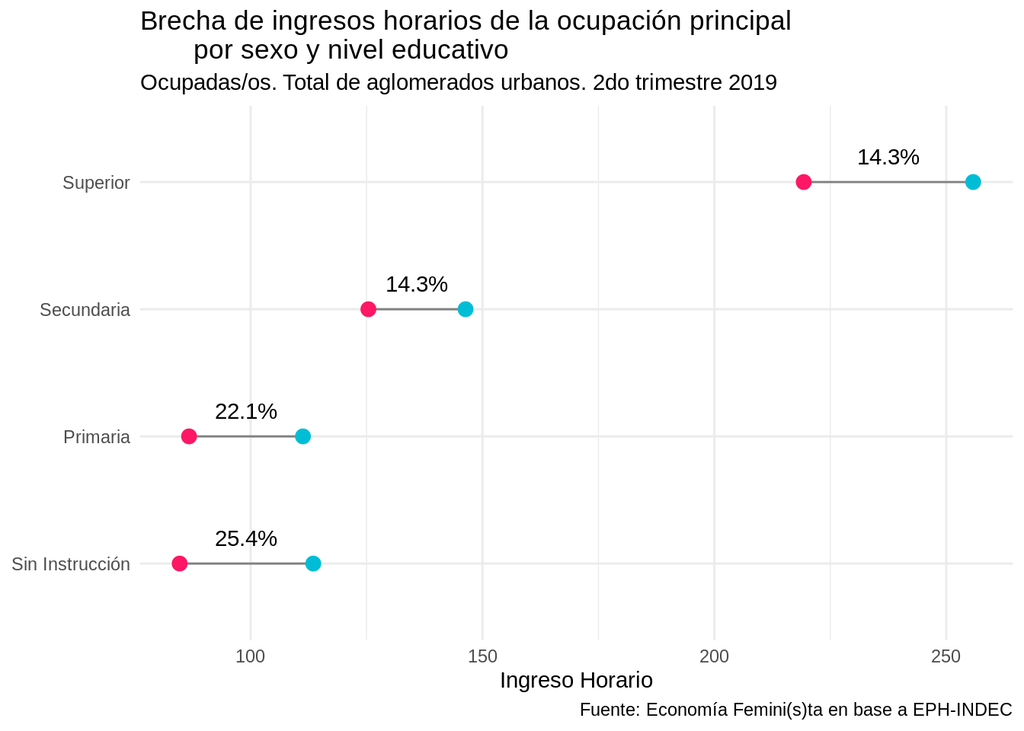

## Horas trabajadas

### Horas trabajadas

La idea de la “brecha” también puede aplicarse para comparar las horas que trabajan en promedio mujeres y varones en el mercado de trabajo, de forma remunerada. De aquí se desprende que, en promedio, las mujeres trabajan menos horas que los varones, y esto explica una parte importante (aunque no toda) de la brecha de ingresos mensuales.  
Cabe cuestionarse entonces respecto al porqué de la diferencia de horas trabajadas por mujeres y por hombres. ¿Existe una falta de voluntad de las mujeres para trabajar? ¿son más “vagas”? ¿o en realidad existe otro motivo por el cual las mujeres deben relegar sus trabajos, del cual los hombres están exentos? Como veremos más adelante, los datos sugieren una estrecha relación con la distribución de las tareas domésticas hacia el interior de los hogares.

**Figura 13.**

**Brechas de horas trabajadas**

Total de aglomerados urbanos. 2do trimestre 2019

| Población | Horas semanales (media) Mujeres | Horas semanales (media) Varones | Brecha |
| --- | --- | --- | --- |
| Ocupadas/os | 31.2 | 40.0 | 22.0% |
| Asalariadas/os | 30.4 | 40.8 | 25.4% |
| Asalariadas/os sin desc. jubil. | 24.7 | 37.0 | 33.4% |

Fuente: Economía Femini(s)ta en base a EPH-INDEC

## Tareas del hogar

### Distribución de las tareas domésticas

El trabajo doméstico suele recaer más en las mujeres que en los varones. Es decir, es más probable que sean éstas las encargadas de realizar tareas de cuidado y reproducción para otros miembros de su hogar. En estos casos, el trabajo no se comercia en el mercado, se realiza entre quienes tienen un vínculo personal, y por tanto no es remunerado.  
A modo ilustrativo, se señala que: **del total de personas que realizan tareas domésticas, un 73% son mujeres y un 27% son varones.** Esto sucede si tenemos en cuenta el total de los hogares, y seguramente la diferencia se agravaría si quitáramos los hogares unipersonales del conteo y/o incluyéramos a las trabajadoras de servicio doméstico.

Este reparto desigual de las tareas domésticas entre varones y mujeres podría asociarse a las desigualdades vistas anteriormente en la composición del mercado de trabajo (obstáculos en el acceso a cargos jerárquicos, precarización laboral, etc ) y responde a un conjunto de normas sociales y estereotipos de género que asignan mandatos diferenciales a varones y mujeres.

Dicha feminización de las tareas de cuidado penaliza a estas últimas, haciendo que enfrenten extensas cargas de trabajo en el hogar y, por ende, imponiendo una fuerte restricción temporal y afectando el acceso al mercado de trabajo y a la trayectoria laboral.

**Figura 14.**

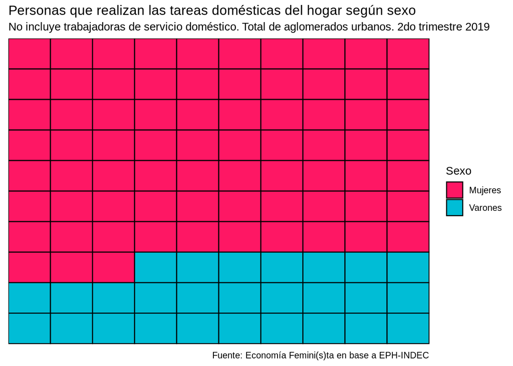

## Distribución del ingreso

### Distribución del Ingreso

Por último, podemos analizar las brechas de género en la distribución de los ingresos. En primer lugar, se ordena por deciles a las personas según su ingreso per cápita familiar (el ingreso total del hogar dividido por la cantidad de personas que lo componen). Es decir, se forman diez grupos de individuos, de igual tamaño, ordenados según el nivel de ingresos que le corresponden por el hogar al que pertenece. En el siguiente gráfico se puede observar la proporción de mujeres y de varones que finalmente componen cada decil.

**Figura 15.**

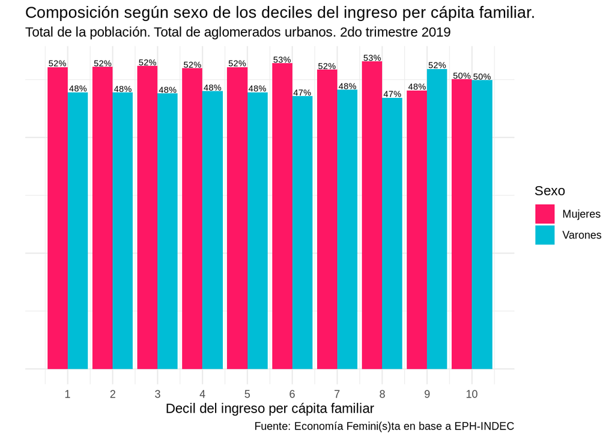

En segundo lugar, se separa a la población en deciles según el ingreso total individual. Es decir, se ordena en base al nivel de ingresos que percibe cada individuo, no el hogar (caso anterior). En este caso puede verse que los deciles más bajos de ingresos están compuestos mayoritariamente por mujeres y, en paralelo, los deciles de mayores ingresos se componen mayoritariamente por varones. Decimos entonces que los estratos de menores ingresos están feminizados, al tiempo que los estratos de mayores ingresos se encuentran masculinizados. ¿Cuál es la diferencia respecto del gráfico anterior?

**Figura 16.**

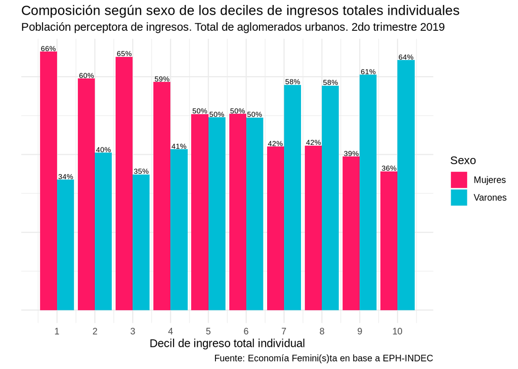

En la figura 15, las unidades de análisis son los hogares, sólo que luego se distribuyeron de forma “pareja” sus ingresos entre los miembros. De esta forma, la composición por sexo de los estratos de menores ingresos no tiene mayores diferencias respecto a la de los estratos de mayores ingresos. En cambio, en la figura 16 vemos lo que pasa a nivel individual, lo cual es una forma de “abrir” hacia el interior de los hogares. La unidad familiar parece resolver la diferencia entre sexos, pero es dentro de ésta que se mantiene la diferencia: de acuerdo a todo lo visto anteriormente, los varones tienen más probabilidades de ganar más que las mujeres del mismo hogar. La distribución de los ingresos de las mujeres, sesgada hacia los menores ingresos, se compensa en la estructura familiar con la distribución de los ingresos de los varones, sesgada hacia los mayores ingresos. Entonces, *la familia como unidad de reproducción esconde y resuelve debajo de la superficie (la distribución aparentemente equitativa según los ingresos per cápita) la inequitativa distribución de las tareas de reproducción y las dificultades asociadas que tienen las mujeres para participar de forma plena en el mercado de trabajo y por tanto percibir ingresos semejantes a los de los varones.*